# Risk Factor Analysis

## Outcome Variable

**Outcome Variable:** stunted

## Predictor Variables

**Intervention Variable:** meducyrs

**Adjustment Set:**

unadjusted

## Stratifying Variables

The analysis was stratified on these variable(s):

- agecat
- studyid
- country

## Data Summary

| agecat | studyid | country | A | n | nA | nAY0 | nAY1 |
| --- | --- | --- | --- | --- | --- | --- | --- |
| Birth | ki0047075b-MAL-ED | BANGLADESH | Q4 | 207 | 59 | 55 | 4 |
| Birth | ki0047075b-MAL-ED | BANGLADESH | Q1 | 207 | 40 | 28 | 12 |
| Birth | ki0047075b-MAL-ED | BANGLADESH | Q2 | 207 | 28 | 23 | 5 |
| Birth | ki0047075b-MAL-ED | BANGLADESH | Q3 | 207 | 80 | 65 | 15 |
| Birth | ki0047075b-MAL-ED | BRAZIL | Q4 | 190 | 65 | 58 | 7 |
| Birth | ki0047075b-MAL-ED | BRAZIL | Q1 | 190 | 40 | 37 | 3 |
| Birth | ki0047075b-MAL-ED | BRAZIL | Q2 | 190 | 36 | 29 | 7 |
| Birth | ki0047075b-MAL-ED | BRAZIL | Q3 | 190 | 49 | 45 | 4 |
| Birth | ki0047075b-MAL-ED | INDIA | Q4 | 183 | 51 | 42 | 9 |
| Birth | ki0047075b-MAL-ED | INDIA | Q1 | 183 | 27 | 24 | 3 |
| Birth | ki0047075b-MAL-ED | INDIA | Q2 | 183 | 43 | 38 | 5 |
| Birth | ki0047075b-MAL-ED | INDIA | Q3 | 183 | 62 | 52 | 10 |
| Birth | ki0047075b-MAL-ED | NEPAL | Q4 | 160 | 13 | 10 | 3 |
| Birth | ki0047075b-MAL-ED | NEPAL | Q1 | 160 | 21 | 19 | 2 |
| Birth | ki0047075b-MAL-ED | NEPAL | Q2 | 160 | 47 | 41 | 6 |
| Birth | ki0047075b-MAL-ED | NEPAL | Q3 | 160 | 79 | 73 | 6 |
| Birth | ki0047075b-MAL-ED | PERU | Q4 | 286 | 87 | 77 | 10 |
| Birth | ki0047075b-MAL-ED | PERU | Q1 | 286 | 60 | 52 | 8 |
| Birth | ki0047075b-MAL-ED | PERU | Q2 | 286 | 67 | 60 | 7 |
| Birth | ki0047075b-MAL-ED | PERU | Q3 | 286 | 72 | 63 | 9 |
| Birth | ki0047075b-MAL-ED | SOUTH AFRICA | Q4 | 262 | 72 | 63 | 9 |
| Birth | ki0047075b-MAL-ED | SOUTH AFRICA | Q1 | 262 | 51 | 49 | 2 |
| Birth | ki0047075b-MAL-ED | SOUTH AFRICA | Q2 | 262 | 82 | 75 | 7 |
| Birth | ki0047075b-MAL-ED | SOUTH AFRICA | Q3 | 262 | 57 | 47 | 10 |
| Birth | ki0047075b-MAL-ED | TANZANIA, UNITED REPUBLIC OF | Q4 | 107 | 2 | 2 | 0 |
| Birth | ki0047075b-MAL-ED | TANZANIA, UNITED REPUBLIC OF | Q1 | 107 | 15 | 14 | 1 |
| Birth | ki0047075b-MAL-ED | TANZANIA, UNITED REPUBLIC OF | Q2 | 107 | 20 | 18 | 2 |
| Birth | ki0047075b-MAL-ED | TANZANIA, UNITED REPUBLIC OF | Q3 | 107 | 70 | 58 | 12 |
| Birth | ki1000108-CMC-V-BCS-2002 | INDIA | Q4 | 90 | 7 | 7 | 0 |
| Birth | ki1000108-CMC-V-BCS-2002 | INDIA | Q1 | 90 | 15 | 13 | 2 |

[output cut: 638 more lines]

The following strata were considered:

- agecat: 12 months, studyid: ki0047075b-MAL-ED, country: BANGLADESH
- agecat: 12 months, studyid: ki0047075b-MAL-ED, country: BRAZIL
- agecat: 12 months, studyid: ki0047075b-MAL-ED, country: INDIA
- agecat: 12 months, studyid: ki0047075b-MAL-ED, country: NEPAL
- agecat: 12 months, studyid: ki0047075b-MAL-ED, country: PERU
- agecat: 12 months, studyid: ki0047075b-MAL-ED, country: SOUTH AFRICA
- agecat: 12 months, studyid: ki0047075b-MAL-ED, country: TANZANIA, UNITED REPUBLIC OF
- agecat: 12 months, studyid: ki1000108-CMC-V-BCS-2002, country: INDIA
- agecat: 12 months, studyid: ki1000108-IRC, country: INDIA
- agecat: 12 months, studyid: ki1000109-EE, country: PAKISTAN
- agecat: 12 months, studyid: ki1000304b-SAS-CompFeed, country: INDIA
- agecat: 12 months, studyid: ki1000304b-SAS-FoodSuppl, country: INDIA
- agecat: 12 months, studyid: ki1017093-NIH-Birth, country: BANGLADESH
- agecat: 12 months, studyid: ki1017093b-PROVIDE, country: BANGLADESH
- agecat: 12 months, studyid: ki1017093c-NIH-Crypto, country: BANGLADESH
- agecat: 12 months, studyid: ki1066203-TanzaniaChild2, country: TANZANIA, UNITED REPUBLIC OF
- agecat: 12 months, studyid: ki1112895-Guatemala BSC, country: GUATEMALA
- agecat: 12 months, studyid: ki1113344-GMS-Nepal, country: NEPAL
- agecat: 12 months, studyid: ki1119695-PROBIT, country: BELARUS
- agecat: 12 months, studyid: ki1126311-ZVITAMBO, country: ZIMBABWE
- agecat: 12 months, studyid: ki1135781-COHORTS, country: GUATEMALA
- agecat: 12 months, studyid: ki1135781-COHORTS, country: INDIA
- agecat: 12 months, studyid: ki1135781-COHORTS, country: PHILIPPINES
- agecat: 12 months, studyid: ki1148112-LCNI-5, country: MALAWI
- agecat: 12 months, studyid: kiGH5241-JiVitA-3, country: BANGLADESH
- agecat: 12 months, studyid: kiGH5241-JiVitA-4, country: BANGLADESH
- agecat: 18 months, studyid: ki0047075b-MAL-ED, country: BANGLADESH
- agecat: 18 months, studyid: ki0047075b-MAL-ED, country: BRAZIL
- agecat: 18 months, studyid: ki0047075b-MAL-ED, country: INDIA
- agecat: 18 months, studyid: ki0047075b-MAL-ED, country: NEPAL
- agecat: 18 months, studyid: ki0047075b-MAL-ED, country: PERU
- agecat: 18 months, studyid: ki0047075b-MAL-ED, country: SOUTH AFRICA
- agecat: 18 months, studyid: ki0047075b-MAL-ED, country: TANZANIA, UNITED REPUBLIC OF
- agecat: 18 months, studyid: ki1000108-CMC-V-BCS-2002, country: INDIA
- agecat: 18 months, studyid: ki1000108-IRC, country: INDIA
- agecat: 18 months, studyid: ki1000109-EE, country: PAKISTAN
- agecat: 18 months, studyid: ki1000304b-SAS-CompFeed, country: INDIA
- agecat: 18 months, studyid: ki1000304b-SAS-FoodSuppl, country: INDIA
- agecat: 18 months, studyid: ki1017093-NIH-Birth, country: BANGLADESH
- agecat: 18 months, studyid: ki1017093b-PROVIDE, country: BANGLADESH
- agecat: 18 months, studyid: ki1017093c-NIH-Crypto, country: BANGLADESH
- agecat: 18 months, studyid: ki1066203-TanzaniaChild2, country: TANZANIA, UNITED REPUBLIC OF
- agecat: 18 months, studyid: ki1113344-GMS-Nepal, country: NEPAL
- agecat: 18 months, studyid: ki1119695-PROBIT, country: BELARUS
- agecat: 18 months, studyid: ki1126311-ZVITAMBO, country: ZIMBABWE
- agecat: 18 months, studyid: ki1135781-COHORTS, country: GUATEMALA
- agecat: 18 months, studyid: ki1135781-COHORTS, country: PHILIPPINES
- agecat: 18 months, studyid: ki1148112-LCNI-5, country: MALAWI
- agecat: 18 months, studyid: kiGH5241-JiVitA-4, country: BANGLADESH
- agecat: 24 months, studyid: ki0047075b-MAL-ED, country: BANGLADESH
- agecat: 24 months, studyid: ki0047075b-MAL-ED, country: BRAZIL
- agecat: 24 months, studyid: ki0047075b-MAL-ED, country: INDIA
- agecat: 24 months, studyid: ki0047075b-MAL-ED, country: NEPAL
- agecat: 24 months, studyid: ki0047075b-MAL-ED, country: PERU
- agecat: 24 months, studyid: ki0047075b-MAL-ED, country: SOUTH AFRICA
- agecat: 24 months, studyid: ki0047075b-MAL-ED, country: TANZANIA, UNITED REPUBLIC OF
- agecat: 24 months, studyid: ki1000108-CMC-V-BCS-2002, country: INDIA
- agecat: 24 months, studyid: ki1000108-IRC, country: INDIA
- agecat: 24 months, studyid: ki1017093-NIH-Birth, country: BANGLADESH
- agecat: 24 months, studyid: ki1017093b-PROVIDE, country: BANGLADESH
- agecat: 24 months, studyid: ki1017093c-NIH-Crypto, country: BANGLADESH
- agecat: 24 months, studyid: ki1066203-TanzaniaChild2, country: TANZANIA, UNITED REPUBLIC OF
- agecat: 24 months, studyid: ki1113344-GMS-Nepal, country: NEPAL
- agecat: 24 months, studyid: ki1119695-PROBIT, country: BELARUS
- agecat: 24 months, studyid: ki1126311-ZVITAMBO, country: ZIMBABWE
- agecat: 24 months, studyid: ki1135781-COHORTS, country: GUATEMALA
- agecat: 24 months, studyid: ki1135781-COHORTS, country: INDIA
- agecat: 24 months, studyid: ki1135781-COHORTS, country: PHILIPPINES
- agecat: 24 months, studyid: ki1148112-LCNI-5, country: MALAWI
- agecat: 24 months, studyid: kiGH5241-JiVitA-3, country: BANGLADESH
- agecat: 24 months, studyid: kiGH5241-JiVitA-4, country: BANGLADESH
- agecat: 3 months, studyid: ki0047075b-MAL-ED, country: BANGLADESH
- agecat: 3 months, studyid: ki0047075b-MAL-ED, country: BRAZIL
- agecat: 3 months, studyid: ki0047075b-MAL-ED, country: INDIA
- agecat: 3 months, studyid: ki0047075b-MAL-ED, country: NEPAL
- agecat: 3 months, studyid: ki0047075b-MAL-ED, country: PERU
- agecat: 3 months, studyid: ki0047075b-MAL-ED, country: SOUTH AFRICA
- agecat: 3 months, studyid: ki0047075b-MAL-ED, country: TANZANIA, UNITED REPUBLIC OF
- agecat: 3 months, studyid: ki1000108-CMC-V-BCS-2002, country: INDIA
- agecat: 3 months, studyid: ki1000108-IRC, country: INDIA
- agecat: 3 months, studyid: ki1000109-EE, country: PAKISTAN
- agecat: 3 months, studyid: ki1000304b-SAS-CompFeed, country: INDIA
- agecat: 3 months, studyid: ki1000304b-SAS-FoodSuppl, country: INDIA
- agecat: 3 months, studyid: ki1017093-NIH-Birth, country: BANGLADESH
- agecat: 3 months, studyid: ki1017093b-PROVIDE, country: BANGLADESH
- agecat: 3 months, studyid: ki1017093c-NIH-Crypto, country: BANGLADESH
- agecat: 3 months, studyid: ki1066203-TanzaniaChild2, country: TANZANIA, UNITED REPUBLIC OF
- agecat: 3 months, studyid: ki1112895-Guatemala BSC, country: GUATEMALA
- agecat: 3 months, studyid: ki1113344-GMS-Nepal, country: NEPAL
- agecat: 3 months, studyid: ki1119695-PROBIT, country: BELARUS
- agecat: 3 months, studyid: ki1126311-ZVITAMBO, country: ZIMBABWE
- agecat: 3 months, studyid: ki1135781-COHORTS, country: GUATEMALA
- agecat: 3 months, studyid: ki1135781-COHORTS, country: INDIA
- agecat: 3 months, studyid: ki1135781-COHORTS, country: PHILIPPINES
- agecat: 3 months, studyid: kiGH5241-JiVitA-3, country: BANGLADESH
- agecat: 3 months, studyid: kiGH5241-JiVitA-4, country: BANGLADESH
- agecat: 6 months, studyid: ki0047075b-MAL-ED, country: BANGLADESH
- agecat: 6 months, studyid: ki0047075b-MAL-ED, country: BRAZIL
- agecat: 6 months, studyid: ki0047075b-MAL-ED, country: INDIA
- agecat: 6 months, studyid: ki0047075b-MAL-ED, country: NEPAL
- agecat: 6 months, studyid: ki0047075b-MAL-ED, country: PERU
- agecat: 6 months, studyid: ki0047075b-MAL-ED, country: SOUTH AFRICA
- agecat: 6 months, studyid: ki0047075b-MAL-ED, country: TANZANIA, UNITED REPUBLIC OF
- agecat: 6 months, studyid: ki1000108-CMC-V-BCS-2002, country: INDIA
- agecat: 6 months, studyid: ki1000108-IRC, country: INDIA
- agecat: 6 months, studyid: ki1000109-EE, country: PAKISTAN
- agecat: 6 months, studyid: ki1000304b-SAS-CompFeed, country: INDIA
- agecat: 6 months, studyid: ki1000304b-SAS-FoodSuppl, country: INDIA
- agecat: 6 months, studyid: ki1017093-NIH-Birth, country: BANGLADESH
- agecat: 6 months, studyid: ki1017093b-PROVIDE, country: BANGLADESH
- agecat: 6 months, studyid: ki1017093c-NIH-Crypto, country: BANGLADESH
- agecat: 6 months, studyid: ki1066203-TanzaniaChild2, country: TANZANIA, UNITED REPUBLIC OF
- agecat: 6 months, studyid: ki1112895-Guatemala BSC, country: GUATEMALA
- agecat: 6 months, studyid: ki1113344-GMS-Nepal, country: NEPAL
- agecat: 6 months, studyid: ki1119695-PROBIT, country: BELARUS
- agecat: 6 months, studyid: ki1126311-ZVITAMBO, country: ZIMBABWE
- agecat: 6 months, studyid: ki1135781-COHORTS, country: GUATEMALA
- agecat: 6 months, studyid: ki1135781-COHORTS, country: INDIA
- agecat: 6 months, studyid: ki1135781-COHORTS, country: PHILIPPINES
- agecat: 6 months, studyid: ki1148112-LCNI-5, country: MALAWI
- agecat: 6 months, studyid: kiGH5241-JiVitA-3, country: BANGLADESH
- agecat: 6 months, studyid: kiGH5241-JiVitA-4, country: BANGLADESH
- agecat: 9 months, studyid: ki0047075b-MAL-ED, country: BANGLADESH
- agecat: 9 months, studyid: ki0047075b-MAL-ED, country: BRAZIL
- agecat: 9 months, studyid: ki0047075b-MAL-ED, country: INDIA
- agecat: 9 months, studyid: ki0047075b-MAL-ED, country: NEPAL
- agecat: 9 months, studyid: ki0047075b-MAL-ED, country: PERU
- agecat: 9 months, studyid: ki0047075b-MAL-ED, country: SOUTH AFRICA
- agecat: 9 months, studyid: ki0047075b-MAL-ED, country: TANZANIA, UNITED REPUBLIC OF
- agecat: 9 months, studyid: ki1000108-CMC-V-BCS-2002, country: INDIA
- agecat: 9 months, studyid: ki1000108-IRC, country: INDIA
- agecat: 9 months, studyid: ki1000109-EE, country: PAKISTAN
- agecat: 9 months, studyid: ki1000304b-SAS-CompFeed, country: INDIA
- agecat: 9 months, studyid: ki1000304b-SAS-FoodSuppl, country: INDIA
- agecat: 9 months, studyid: ki1017093-NIH-Birth, country: BANGLADESH
- agecat: 9 months, studyid: ki1017093b-PROVIDE, country: BANGLADESH
- agecat: 9 months, studyid: ki1017093c-NIH-Crypto, country: BANGLADESH
- agecat: 9 months, studyid: ki1066203-TanzaniaChild2, country: TANZANIA, UNITED REPUBLIC OF
- agecat: 9 months, studyid: ki1112895-Guatemala BSC, country: GUATEMALA
- agecat: 9 months, studyid: ki1113344-GMS-Nepal, country: NEPAL
- agecat: 9 months, studyid: ki1119695-PROBIT, country: BELARUS
- agecat: 9 months, studyid: ki1126311-ZVITAMBO, country: ZIMBABWE
- agecat: 9 months, studyid: ki1135781-COHORTS, country: GUATEMALA
- agecat: 9 months, studyid: ki1135781-COHORTS, country: INDIA
- agecat: 9 months, studyid: ki1135781-COHORTS, country: PHILIPPINES
- agecat: 9 months, studyid: ki1148112-LCNI-5, country: MALAWI
- agecat: 9 months, studyid: kiGH5241-JiVitA-4, country: BANGLADESH
- agecat: Birth, studyid: ki0047075b-MAL-ED, country: BANGLADESH
- agecat: Birth, studyid: ki0047075b-MAL-ED, country: BRAZIL
- agecat: Birth, studyid: ki0047075b-MAL-ED, country: INDIA
- agecat: Birth, studyid: ki0047075b-MAL-ED, country: NEPAL
- agecat: Birth, studyid: ki0047075b-MAL-ED, country: PERU
- agecat: Birth, studyid: ki0047075b-MAL-ED, country: SOUTH AFRICA
- agecat: Birth, studyid: ki0047075b-MAL-ED, country: TANZANIA, UNITED REPUBLIC OF
- agecat: Birth, studyid: ki1000108-CMC-V-BCS-2002, country: INDIA
- agecat: Birth, studyid: ki1000108-IRC, country: INDIA
- agecat: Birth, studyid: ki1000109-EE, country: PAKISTAN
- agecat: Birth, studyid: ki1000304b-SAS-CompFeed, country: INDIA
- agecat: Birth, studyid: ki1017093-NIH-Birth, country: BANGLADESH
- agecat: Birth, studyid: ki1017093c-NIH-Crypto, country: BANGLADESH
- agecat: Birth, studyid: ki1119695-PROBIT, country: BELARUS
- agecat: Birth, studyid: ki1126311-ZVITAMBO, country: ZIMBABWE
- agecat: Birth, studyid: ki1135781-COHORTS, country: GUATEMALA
- agecat: Birth, studyid: ki1135781-COHORTS, country: INDIA
- agecat: Birth, studyid: ki1135781-COHORTS, country: PHILIPPINES
- agecat: Birth, studyid: kiGH5241-JiVitA-3, country: BANGLADESH
- agecat: Birth, studyid: kiGH5241-JiVitA-4, country: BANGLADESH

### Dropped Strata

Some strata were dropped due to rare outcomes:

- agecat: Birth, studyid: ki0047075b-MAL-ED, country: BANGLADESH
- agecat: Birth, studyid: ki0047075b-MAL-ED, country: BRAZIL
- agecat: Birth, studyid: ki0047075b-MAL-ED, country: INDIA
- agecat: Birth, studyid: ki0047075b-MAL-ED, country: NEPAL
- agecat: Birth, studyid: ki0047075b-MAL-ED, country: SOUTH AFRICA
- agecat: Birth, studyid: ki0047075b-MAL-ED, country: TANZANIA, UNITED REPUBLIC OF
- agecat: Birth, studyid: ki1000108-CMC-V-BCS-2002, country: INDIA
- agecat: Birth, studyid: ki1000108-IRC, country: INDIA
- agecat: Birth, studyid: ki1000109-EE, country: PAKISTAN
- agecat: Birth, studyid: ki1000304b-SAS-CompFeed, country: INDIA
- agecat: Birth, studyid: ki1017093-NIH-Birth, country: BANGLADESH
- agecat: Birth, studyid: ki1017093c-NIH-Crypto, country: BANGLADESH
- agecat: Birth, studyid: ki1119695-PROBIT, country: BELARUS
- agecat: Birth, studyid: ki1135781-COHORTS, country: GUATEMALA
- agecat: Birth, studyid: kiGH5241-JiVitA-4, country: BANGLADESH
- agecat: 3 months, studyid: ki0047075b-MAL-ED, country: BANGLADESH
- agecat: 3 months, studyid: ki0047075b-MAL-ED, country: BRAZIL
- agecat: 3 months, studyid: ki0047075b-MAL-ED, country: INDIA
- agecat: 3 months, studyid: ki0047075b-MAL-ED, country: NEPAL
- agecat: 3 months, studyid: ki0047075b-MAL-ED, country: TANZANIA, UNITED REPUBLIC OF
- agecat: 3 months, studyid: ki1000108-CMC-V-BCS-2002, country: INDIA
- agecat: 3 months, studyid: ki1000108-IRC, country: INDIA
- agecat: 3 months, studyid: ki1000109-EE, country: PAKISTAN
- agecat: 3 months, studyid: ki1000304b-SAS-CompFeed, country: INDIA
- agecat: 3 months, studyid: ki1000304b-SAS-FoodSuppl, country: INDIA
- agecat: 3 months, studyid: ki1017093b-PROVIDE, country: BANGLADESH
- agecat: 3 months, studyid: ki1066203-TanzaniaChild2, country: TANZANIA, UNITED REPUBLIC OF
- agecat: 3 months, studyid: ki1112895-Guatemala BSC, country: GUATEMALA
- agecat: 3 months, studyid: ki1113344-GMS-Nepal, country: NEPAL
- agecat: 3 months, studyid: ki1119695-PROBIT, country: BELARUS
- agecat: 3 months, studyid: ki1135781-COHORTS, country: GUATEMALA
- agecat: 3 months, studyid: kiGH5241-JiVitA-4, country: BANGLADESH
- agecat: 6 months, studyid: ki0047075b-MAL-ED, country: BANGLADESH
- agecat: 6 months, studyid: ki0047075b-MAL-ED, country: BRAZIL
- agecat: 6 months, studyid: ki0047075b-MAL-ED, country: NEPAL
- agecat: 6 months, studyid: ki0047075b-MAL-ED, country: TANZANIA, UNITED REPUBLIC OF
- agecat: 6 months, studyid: ki1000108-IRC, country: INDIA
- agecat: 6 months, studyid: ki1000109-EE, country: PAKISTAN
- agecat: 6 months, studyid: ki1000304b-SAS-CompFeed, country: INDIA
- agecat: 6 months, studyid: ki1000304b-SAS-FoodSuppl, country: INDIA
- agecat: 6 months, studyid: ki1017093b-PROVIDE, country: BANGLADESH
- agecat: 6 months, studyid: ki1066203-TanzaniaChild2, country: TANZANIA, UNITED REPUBLIC OF
- agecat: 6 months, studyid: ki1119695-PROBIT, country: BELARUS
- agecat: 6 months, studyid: ki1135781-COHORTS, country: GUATEMALA
- agecat: 6 months, studyid: ki1148112-LCNI-5, country: MALAWI
- agecat: 6 months, studyid: kiGH5241-JiVitA-4, country: BANGLADESH
- agecat: 9 months, studyid: ki0047075b-MAL-ED, country: BANGLADESH
- agecat: 9 months, studyid: ki0047075b-MAL-ED, country: BRAZIL
- agecat: 9 months, studyid: ki0047075b-MAL-ED, country: INDIA
- agecat: 9 months, studyid: ki0047075b-MAL-ED, country: NEPAL
- agecat: 9 months, studyid: ki0047075b-MAL-ED, country: TANZANIA, UNITED REPUBLIC OF
- agecat: 9 months, studyid: ki1000108-IRC, country: INDIA
- agecat: 9 months, studyid: ki1000109-EE, country: PAKISTAN
- agecat: 9 months, studyid: ki1000304b-SAS-CompFeed, country: INDIA
- agecat: 9 months, studyid: ki1000304b-SAS-FoodSuppl, country: INDIA
- agecat: 9 months, studyid: ki1017093b-PROVIDE, country: BANGLADESH
- agecat: 9 months, studyid: ki1066203-TanzaniaChild2, country: TANZANIA, UNITED REPUBLIC OF
- agecat: 9 months, studyid: ki1119695-PROBIT, country: BELARUS
- agecat: 9 months, studyid: ki1135781-COHORTS, country: GUATEMALA
- agecat: 9 months, studyid: ki1148112-LCNI-5, country: MALAWI
- agecat: 9 months, studyid: kiGH5241-JiVitA-4, country: BANGLADESH
- agecat: 12 months, studyid: ki0047075b-MAL-ED, country: BRAZIL
- agecat: 12 months, studyid: ki0047075b-MAL-ED, country: NEPAL
- agecat: 12 months, studyid: ki0047075b-MAL-ED, country: TANZANIA, UNITED REPUBLIC OF
- agecat: 12 months, studyid: ki1000108-IRC, country: INDIA
- agecat: 12 months, studyid: ki1000109-EE, country: PAKISTAN
- agecat: 12 months, studyid: ki1000304b-SAS-CompFeed, country: INDIA
- agecat: 12 months, studyid: ki1000304b-SAS-FoodSuppl, country: INDIA
- agecat: 12 months, studyid: ki1017093b-PROVIDE, country: BANGLADESH
- agecat: 12 months, studyid: ki1066203-TanzaniaChild2, country: TANZANIA, UNITED REPUBLIC OF
- agecat: 12 months, studyid: ki1119695-PROBIT, country: BELARUS
- agecat: 12 months, studyid: ki1135781-COHORTS, country: GUATEMALA
- agecat: 12 months, studyid: ki1148112-LCNI-5, country: MALAWI
- agecat: 12 months, studyid: kiGH5241-JiVitA-4, country: BANGLADESH
- agecat: 18 months, studyid: ki0047075b-MAL-ED, country: BRAZIL
- agecat: 18 months, studyid: ki0047075b-MAL-ED, country: NEPAL
- agecat: 18 months, studyid: ki0047075b-MAL-ED, country: TANZANIA, UNITED REPUBLIC OF
- agecat: 18 months, studyid: ki1000108-IRC, country: INDIA
- agecat: 18 months, studyid: ki1000109-EE, country: PAKISTAN
- agecat: 18 months, studyid: ki1000304b-SAS-CompFeed, country: INDIA
- agecat: 18 months, studyid: ki1000304b-SAS-FoodSuppl, country: INDIA
- agecat: 18 months, studyid: ki1017093b-PROVIDE, country: BANGLADESH
- agecat: 18 months, studyid: ki1066203-TanzaniaChild2, country: TANZANIA, UNITED REPUBLIC OF
- agecat: 18 months, studyid: ki1119695-PROBIT, country: BELARUS
- agecat: 18 months, studyid: ki1135781-COHORTS, country: GUATEMALA
- agecat: 18 months, studyid: ki1148112-LCNI-5, country: MALAWI
- agecat: 18 months, studyid: kiGH5241-JiVitA-4, country: BANGLADESH
- agecat: 24 months, studyid: ki0047075b-MAL-ED, country: BRAZIL
- agecat: 24 months, studyid: ki0047075b-MAL-ED, country: NEPAL
- agecat: 24 months, studyid: ki0047075b-MAL-ED, country: TANZANIA, UNITED REPUBLIC OF
- agecat: 24 months, studyid: ki1000108-IRC, country: INDIA
- agecat: 24 months, studyid: ki1017093b-PROVIDE, country: BANGLADESH
- agecat: 24 months, studyid: ki1066203-TanzaniaChild2, country: TANZANIA, UNITED REPUBLIC OF
- agecat: 24 months, studyid: ki1119695-PROBIT, country: BELARUS
- agecat: 24 months, studyid: ki1126311-ZVITAMBO, country: ZIMBABWE
- agecat: 24 months, studyid: ki1135781-COHORTS, country: GUATEMALA
- agecat: 24 months, studyid: ki1148112-LCNI-5, country: MALAWI
- agecat: 24 months, studyid: kiGH5241-JiVitA-4, country: BANGLADESH

## Methods Detail

We’re interested in the causal parameters $E[Y_a]$ for all values of $a \in \mathcal{A}$. These parameters represent the mean outcome if, possibly contrary to fact, we intervened to set all units to have $A=a$. Under the randomization and positivity assumptions, these are identified by the statistical parameters $\psi_a=E_W[E_{Y|A,W}(Y|A=a,W)]$. In addition, we’re interested in the mean of $Y$, $E[Y]$ under no intervention (the observed mean). We will estimate these parameters by using SuperLearner to fit the relevant likelihood factors – $E_{Y|A,W}(Y|A=a,W)$ and $p(A=a|W)$, and then updating our likelihood fit using a joint TMLE.

For unadjusted analyses ($W=\{\}$), initial likelihoods were estimated using Lrnr_glm to estimate the simple $E(Y|A)$ and Lrnr_mean to estimate $p(A)$. For adjusted analyses, a small library containing Lrnr_glmnet, Lrnr_xgboost, and Lrnr_mean was used.

Having estimated these parameters, we will then use the delta method to estimate relative risks and attributable risks relative to a prespecified baseline level of $A$.

# Results Detail

## Results Plots

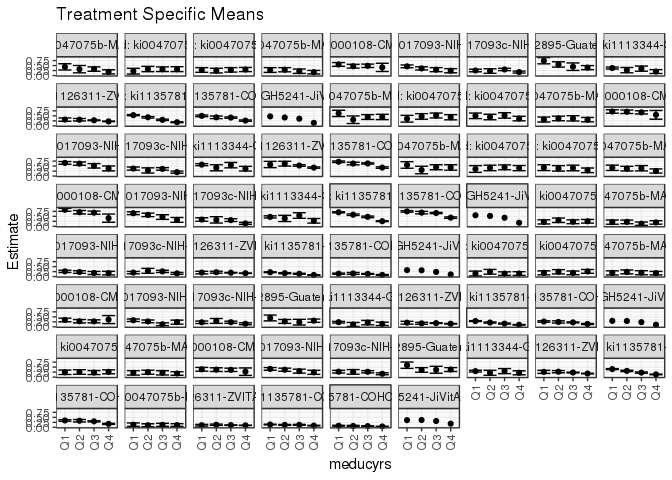

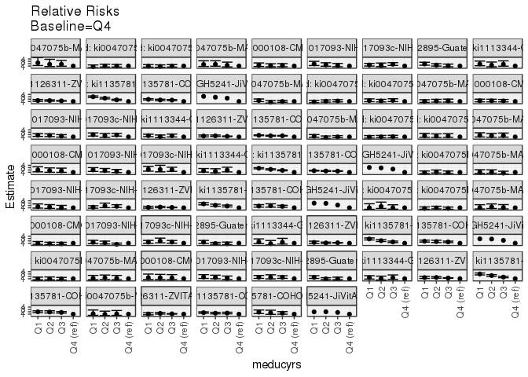

[figure not shown]

[figure not shown]

## Results Table

### Parameter: TSM

| agecat | studyid | country | intervention_level | baseline_level | estimate | ci_lower | ci_upper |
| --- | --- | --- | --- | --- | --- | --- | --- |
| Birth | ki0047075b-MAL-ED | PERU | Q4 | NA | 0.1149425 | 0.0478035 | 0.1820816 |
| Birth | ki0047075b-MAL-ED | PERU | Q1 | NA | 0.1333333 | 0.0471688 | 0.2194979 |
| Birth | ki0047075b-MAL-ED | PERU | Q2 | NA | 0.1044776 | 0.0311072 | 0.1778481 |
| Birth | ki0047075b-MAL-ED | PERU | Q3 | NA | 0.1250000 | 0.0484753 | 0.2015247 |
| Birth | ki1126311-ZVITAMBO | ZIMBABWE | Q4 | NA | 0.0986547 | 0.0923874 | 0.1049221 |
| Birth | ki1126311-ZVITAMBO | ZIMBABWE | Q1 | NA | 0.1057692 | 0.0639730 | 0.1475654 |
| Birth | ki1126311-ZVITAMBO | ZIMBABWE | Q2 | NA | 0.1309524 | 0.0986884 | 0.1632163 |
| Birth | ki1126311-ZVITAMBO | ZIMBABWE | Q3 | NA | 0.1108138 | 0.1016268 | 0.1200009 |
| Birth | ki1135781-COHORTS | INDIA | Q4 | NA | 0.0875995 | 0.0743828 | 0.1008163 |
| Birth | ki1135781-COHORTS | INDIA | Q1 | NA | 0.1429385 | 0.1265663 | 0.1593107 |
| Birth | ki1135781-COHORTS | INDIA | Q2 | NA | 0.1228669 | 0.1011626 | 0.1445712 |
| Birth | ki1135781-COHORTS | INDIA | Q3 | NA | 0.1263670 | 0.1036646 | 0.1490693 |
| Birth | ki1135781-COHORTS | PHILIPPINES | Q4 | NA | 0.0439443 | 0.0307899 | 0.0570987 |
| Birth | ki1135781-COHORTS | PHILIPPINES | Q1 | NA | 0.0815047 | 0.0602704 | 0.1027390 |
| Birth | ki1135781-COHORTS | PHILIPPINES | Q2 | NA | 0.0687023 | 0.0380687 | 0.0993359 |
| Birth | ki1135781-COHORTS | PHILIPPINES | Q3 | NA | 0.0624486 | 0.0488520 | 0.0760453 |
| Birth | kiGH5241-JiVitA-3 | BANGLADESH | Q4 | NA | 0.1831832 | NA | NA |
| Birth | kiGH5241-JiVitA-3 | BANGLADESH | Q1 | NA | 0.3595707 | NA | NA |
| Birth | kiGH5241-JiVitA-3 | BANGLADESH | Q2 | NA | 0.3670886 | NA | NA |
| Birth | kiGH5241-JiVitA-3 | BANGLADESH | Q3 | NA | 0.3170426 | NA | NA |
| 3 months | ki0047075b-MAL-ED | PERU | Q4 | NA | 0.2528736 | 0.1613807 | 0.3443664 |
| 3 months | ki0047075b-MAL-ED | PERU | Q1 | NA | 0.2222222 | 0.1193852 | 0.3250592 |
| 3 months | ki0047075b-MAL-ED | PERU | Q2 | NA | 0.3030303 | 0.1919656 | 0.4140950 |
| 3 months | ki0047075b-MAL-ED | PERU | Q3 | NA | 0.2297297 | 0.1337206 | 0.3257388 |
| 3 months | ki0047075b-MAL-ED | SOUTH AFRICA | Q4 | NA | 0.1951220 | 0.1091942 | 0.2810497 |
| 3 months | ki0047075b-MAL-ED | SOUTH AFRICA | Q1 | NA | 0.2105263 | 0.1045017 | 0.3165510 |
| 3 months | ki0047075b-MAL-ED | SOUTH AFRICA | Q2 | NA | 0.2222222 | 0.1315235 | 0.3129210 |
| 3 months | ki0047075b-MAL-ED | SOUTH AFRICA | Q3 | NA | 0.1311475 | 0.0462861 | 0.2160090 |
| 3 months | ki1017093-NIH-Birth | BANGLADESH | Q4 | NA | 0.1739130 | 0.0844005 | 0.2634256 |
| 3 months | ki1017093-NIH-Birth | BANGLADESH | Q1 | NA | 0.2627119 | 0.2065124 | 0.3189113 |

[output cut: 246 more lines]

### Parameter: E(Y)

| agecat | studyid | country | intervention_level | baseline_level | estimate | ci_lower | ci_upper |
| --- | --- | --- | --- | --- | --- | --- | --- |
| Birth | ki0047075b-MAL-ED | PERU | NA | NA | 0.1188811 | 0.0813061 | 0.1564562 |
| Birth | ki1126311-ZVITAMBO | ZIMBABWE | NA | NA | 0.1036930 | 0.0986082 | 0.1087777 |
| Birth | ki1135781-COHORTS | INDIA | NA | NA | 0.1182899 | 0.1095248 | 0.1270550 |
| Birth | ki1135781-COHORTS | PHILIPPINES | NA | NA | 0.0613115 | 0.0527962 | 0.0698268 |
| Birth | kiGH5241-JiVitA-3 | BANGLADESH | NA | NA | 0.3413506 | NA | NA |
| 3 months | ki0047075b-MAL-ED | PERU | NA | NA | 0.2517241 | 0.2016870 | 0.3017613 |
| 3 months | ki0047075b-MAL-ED | SOUTH AFRICA | NA | NA | 0.1921708 | 0.1460207 | 0.2383209 |
| 3 months | ki1017093-NIH-Birth | BANGLADESH | NA | NA | 0.2280702 | 0.1935943 | 0.2625460 |
| 3 months | ki1017093c-NIH-Crypto | BANGLADESH | NA | NA | 0.2142857 | 0.1844587 | 0.2441127 |
| 3 months | ki1126311-ZVITAMBO | ZIMBABWE | NA | NA | 0.1783613 | 0.1705290 | 0.1861936 |
| 3 months | ki1135781-COHORTS | INDIA | NA | NA | 0.1513728 | 0.1419307 | 0.1608150 |
| 3 months | ki1135781-COHORTS | PHILIPPINES | NA | NA | 0.1234783 | 0.1114506 | 0.1355059 |
| 3 months | kiGH5241-JiVitA-3 | BANGLADESH | NA | NA | 0.2768555 | NA | NA |
| 6 months | ki0047075b-MAL-ED | INDIA | NA | NA | 0.1730769 | 0.1215404 | 0.2246134 |
| 6 months | ki0047075b-MAL-ED | PERU | NA | NA | 0.2205882 | 0.1712211 | 0.2699554 |
| 6 months | ki0047075b-MAL-ED | SOUTH AFRICA | NA | NA | 0.1968504 | 0.1478551 | 0.2458457 |
| 6 months | ki1000108-CMC-V-BCS-2002 | INDIA | NA | NA | 0.3008130 | 0.2539566 | 0.3476694 |
| 6 months | ki1017093-NIH-Birth | BANGLADESH | NA | NA | 0.2681564 | 0.2306532 | 0.3056597 |
| 6 months | ki1017093c-NIH-Crypto | BANGLADESH | NA | NA | 0.2097902 | 0.1799252 | 0.2396552 |
| 6 months | ki1112895-Guatemala BSC | GUATEMALA | NA | NA | 0.3104693 | 0.2558835 | 0.3650551 |
| 6 months | ki1113344-GMS-Nepal | NEPAL | NA | NA | 0.2125000 | 0.1785885 | 0.2464115 |
| 6 months | ki1126311-ZVITAMBO | ZIMBABWE | NA | NA | 0.1665057 | 0.1584820 | 0.1745293 |
| 6 months | ki1135781-COHORTS | INDIA | NA | NA | 0.1915758 | 0.1810911 | 0.2020606 |
| 6 months | ki1135781-COHORTS | PHILIPPINES | NA | NA | 0.2112260 | 0.1958496 | 0.2266024 |
| 6 months | kiGH5241-JiVitA-3 | BANGLADESH | NA | NA | 0.2617644 | NA | NA |
| 9 months | ki0047075b-MAL-ED | PERU | NA | NA | 0.2470588 | 0.1940178 | 0.3000999 |
| 9 months | ki0047075b-MAL-ED | SOUTH AFRICA | NA | NA | 0.2120000 | 0.1612332 | 0.2627668 |
| 9 months | ki1000108-CMC-V-BCS-2002 | INDIA | NA | NA | 0.3688525 | 0.3193538 | 0.4183511 |
| 9 months | ki1017093-NIH-Birth | BANGLADESH | NA | NA | 0.3570020 | 0.3152562 | 0.3987478 |
| 9 months | ki1017093c-NIH-Crypto | BANGLADESH | NA | NA | 0.2322946 | 0.2011222 | 0.2634670 |
| 9 months | ki1112895-Guatemala BSC | GUATEMALA | NA | NA | 0.4051724 | 0.3418646 | 0.4684803 |
| 9 months | ki1113344-GMS-Nepal | NEPAL | NA | NA | 0.2823315 | 0.2446438 | 0.3200192 |
| 9 months | ki1126311-ZVITAMBO | ZIMBABWE | NA | NA | 0.1982252 | 0.1892987 | 0.2071518 |
| 9 months | ki1135781-COHORTS | INDIA | NA | NA | 0.2647555 | 0.2521992 | 0.2773117 |
| 9 months | ki1135781-COHORTS | PHILIPPINES | NA | NA | 0.2750737 | 0.2582642 | 0.2918832 |
| 12 months | ki0047075b-MAL-ED | BANGLADESH | NA | NA | 0.3068783 | 0.2409523 | 0.3728043 |
| 12 months | ki0047075b-MAL-ED | INDIA | NA | NA | 0.3050000 | 0.2410318 | 0.3689682 |
| 12 months | ki0047075b-MAL-ED | PERU | NA | NA | 0.2816327 | 0.2251951 | 0.3380702 |
| 12 months | ki0047075b-MAL-ED | SOUTH AFRICA | NA | NA | 0.2380952 | 0.1854042 | 0.2907863 |
| 12 months | ki1000108-CMC-V-BCS-2002 | INDIA | NA | NA | 0.4972826 | 0.4461287 | 0.5484365 |
| 12 months | ki1017093-NIH-Birth | BANGLADESH | NA | NA | 0.3747454 | 0.3318860 | 0.4176049 |
| 12 months | ki1017093c-NIH-Crypto | BANGLADESH | NA | NA | 0.2422096 | 0.2105851 | 0.2738341 |
| 12 months | ki1112895-Guatemala BSC | GUATEMALA | NA | NA | 0.5000000 | 0.4305309 | 0.5694691 |
| 12 months | ki1113344-GMS-Nepal | NEPAL | NA | NA | 0.3441441 | 0.3045831 | 0.3837052 |
| 12 months | ki1126311-ZVITAMBO | ZIMBABWE | NA | NA | 0.2445862 | 0.2343251 | 0.2548473 |
| 12 months | ki1135781-COHORTS | INDIA | NA | NA | 0.3515166 | 0.3371659 | 0.3658673 |
| 12 months | ki1135781-COHORTS | PHILIPPINES | NA | NA | 0.3868472 | 0.3680689 | 0.4056255 |
| 12 months | kiGH5241-JiVitA-3 | BANGLADESH | NA | NA | 0.3962500 | NA | NA |
| 18 months | ki0047075b-MAL-ED | BANGLADESH | NA | NA | 0.4611111 | 0.3880857 | 0.5341365 |
| 18 months | ki0047075b-MAL-ED | INDIA | NA | NA | 0.4550000 | 0.3858128 | 0.5241872 |
| 18 months | ki0047075b-MAL-ED | PERU | NA | NA | 0.4479638 | 0.3822522 | 0.5136754 |
| 18 months | ki0047075b-MAL-ED | SOUTH AFRICA | NA | NA | 0.3402490 | 0.2803070 | 0.4001909 |
| 18 months | ki1000108-CMC-V-BCS-2002 | INDIA | NA | NA | 0.6883469 | 0.6410248 | 0.7356689 |
| 18 months | ki1017093-NIH-Birth | BANGLADESH | NA | NA | 0.5874730 | 0.5425832 | 0.6323628 |
| 18 months | ki1017093c-NIH-Crypto | BANGLADESH | NA | NA | 0.3012618 | 0.2655201 | 0.3370036 |
| 18 months | ki1113344-GMS-Nepal | NEPAL | NA | NA | 0.5338208 | 0.4919775 | 0.5756641 |
| 18 months | ki1126311-ZVITAMBO | ZIMBABWE | NA | NA | 0.4754098 | 0.4517193 | 0.4991004 |
| 18 months | ki1135781-COHORTS | PHILIPPINES | NA | NA | 0.5874799 | 0.5681478 | 0.6068121 |
| 24 months | ki0047075b-MAL-ED | BANGLADESH | NA | NA | 0.4444444 | 0.3697487 | 0.5191402 |
| 24 months | ki0047075b-MAL-ED | INDIA | NA | NA | 0.4070352 | 0.3386053 | 0.4754651 |
| 24 months | ki0047075b-MAL-ED | PERU | NA | NA | 0.3700000 | 0.3029201 | 0.4370799 |
| 24 months | ki0047075b-MAL-ED | SOUTH AFRICA | NA | NA | 0.3529412 | 0.2921001 | 0.4137823 |
| 24 months | ki1000108-CMC-V-BCS-2002 | INDIA | NA | NA | 0.7150538 | 0.6691221 | 0.7609854 |
| 24 months | ki1017093-NIH-Birth | BANGLADESH | NA | NA | 0.5547786 | 0.5076945 | 0.6018626 |
| 24 months | ki1017093c-NIH-Crypto | BANGLADESH | NA | NA | 0.2568093 | 0.2190047 | 0.2946140 |
| 24 months | ki1113344-GMS-Nepal | NEPAL | NA | NA | 0.4495968 | 0.4057742 | 0.4934193 |
| 24 months | ki1135781-COHORTS | INDIA | NA | NA | 0.4815520 | 0.4664409 | 0.4966632 |
| 24 months | ki1135781-COHORTS | PHILIPPINES | NA | NA | 0.6167689 | 0.5974942 | 0.6360437 |
| 24 months | kiGH5241-JiVitA-3 | BANGLADESH | NA | NA | 0.4814556 | NA | NA |

### Parameter: RR

| agecat | studyid | country | intervention_level | baseline_level | estimate | ci_lower | ci_upper |
| --- | --- | --- | --- | --- | --- | --- | --- |
| Birth | ki0047075b-MAL-ED | PERU | Q4 | Q4 | 1.0000000 | 1.0000000 | 1.000000 |
| Birth | ki0047075b-MAL-ED | PERU | Q1 | Q4 | 1.1600000 | 0.4854531 | 2.771844 |
| Birth | ki0047075b-MAL-ED | PERU | Q2 | Q4 | 0.9089552 | 0.3646239 | 2.265895 |
| Birth | ki0047075b-MAL-ED | PERU | Q3 | Q4 | 1.0875000 | 0.4666067 | 2.534589 |
| Birth | ki1126311-ZVITAMBO | ZIMBABWE | Q4 | Q4 | 1.0000000 | 1.0000000 | 1.000000 |
| Birth | ki1126311-ZVITAMBO | ZIMBABWE | Q1 | Q4 | 1.0721154 | 0.7184895 | 1.599789 |
| Birth | ki1126311-ZVITAMBO | ZIMBABWE | Q2 | Q4 | 1.3273809 | 1.0291878 | 1.711971 |
| Birth | ki1126311-ZVITAMBO | ZIMBABWE | Q3 | Q4 | 1.1232492 | 1.0118486 | 1.246915 |
| Birth | ki1135781-COHORTS | INDIA | Q4 | Q4 | 1.0000000 | 1.0000000 | 1.000000 |
| Birth | ki1135781-COHORTS | INDIA | Q1 | Q4 | 1.6317265 | 1.3501420 | 1.972038 |
| Birth | ki1135781-COHORTS | INDIA | Q2 | Q4 | 1.4025974 | 1.1118380 | 1.769394 |
| Birth | ki1135781-COHORTS | INDIA | Q3 | Q4 | 1.4425526 | 1.1408908 | 1.823976 |
| Birth | ki1135781-COHORTS | PHILIPPINES | Q4 | Q4 | 1.0000000 | 1.0000000 | 1.000000 |
| Birth | ki1135781-COHORTS | PHILIPPINES | Q1 | Q4 | 1.8547289 | 1.2471976 | 2.758199 |
| Birth | ki1135781-COHORTS | PHILIPPINES | Q2 | Q4 | 1.5633960 | 0.9137570 | 2.674898 |
| Birth | ki1135781-COHORTS | PHILIPPINES | Q3 | Q4 | 1.4210874 | 0.9814470 | 2.057665 |
| Birth | kiGH5241-JiVitA-3 | BANGLADESH | Q4 | Q4 | 1.0000000 | NA | NA |
| Birth | kiGH5241-JiVitA-3 | BANGLADESH | Q1 | Q4 | 1.9629021 | NA | NA |
| Birth | kiGH5241-JiVitA-3 | BANGLADESH | Q2 | Q4 | 2.0039427 | NA | NA |
| Birth | kiGH5241-JiVitA-3 | BANGLADESH | Q3 | Q4 | 1.7307408 | NA | NA |
| 3 months | ki0047075b-MAL-ED | PERU | Q4 | Q4 | 1.0000000 | 1.0000000 | 1.000000 |
| 3 months | ki0047075b-MAL-ED | PERU | Q1 | Q4 | 0.8787879 | 0.4883949 | 1.581237 |
| 3 months | ki0047075b-MAL-ED | PERU | Q2 | Q4 | 1.1983471 | 0.7160022 | 2.005630 |
| 3 months | ki0047075b-MAL-ED | PERU | Q3 | Q4 | 0.9084767 | 0.5226896 | 1.579006 |
| 3 months | ki0047075b-MAL-ED | SOUTH AFRICA | Q4 | Q4 | 1.0000000 | 1.0000000 | 1.000000 |
| 3 months | ki0047075b-MAL-ED | SOUTH AFRICA | Q1 | Q4 | 1.0789474 | 0.5526576 | 2.106417 |
| 3 months | ki0047075b-MAL-ED | SOUTH AFRICA | Q2 | Q4 | 1.1388889 | 0.6247668 | 2.076083 |
| 3 months | ki0047075b-MAL-ED | SOUTH AFRICA | Q3 | Q4 | 0.6721311 | 0.3072757 | 1.470212 |
| 3 months | ki1017093-NIH-Birth | BANGLADESH | Q4 | Q4 | 1.0000000 | 1.0000000 | 1.000000 |
| 3 months | ki1017093-NIH-Birth | BANGLADESH | Q1 | Q4 | 1.5105932 | 0.8651263 | 2.637640 |

[output cut: 246 more lines]

### Parameter: PAR

| agecat | studyid | country | intervention_level | baseline_level | estimate | ci_lower | ci_upper |
| --- | --- | --- | --- | --- | --- | --- | --- |
| Birth | ki0047075b-MAL-ED | PERU | Q4 | NA | 0.0039386 | -0.0524273 | 0.0603045 |
| Birth | ki1126311-ZVITAMBO | ZIMBABWE | Q4 | NA | 0.0050383 | 0.0010809 | 0.0089956 |
| Birth | ki1135781-COHORTS | INDIA | Q4 | NA | 0.0306903 | 0.0191249 | 0.0422558 |
| Birth | ki1135781-COHORTS | PHILIPPINES | Q4 | NA | 0.0173672 | 0.0055484 | 0.0291860 |
| Birth | kiGH5241-JiVitA-3 | BANGLADESH | Q4 | NA | 0.1581674 | NA | NA |
| 3 months | ki0047075b-MAL-ED | PERU | Q4 | NA | -0.0011494 | -0.0776484 | 0.0753496 |
| 3 months | ki0047075b-MAL-ED | SOUTH AFRICA | Q4 | NA | -0.0029511 | -0.0750908 | 0.0691885 |
| 3 months | ki1017093-NIH-Birth | BANGLADESH | Q4 | NA | 0.0541571 | -0.0310556 | 0.1393699 |
| 3 months | ki1017093c-NIH-Crypto | BANGLADESH | Q4 | NA | 0.0537919 | 0.0138086 | 0.0937752 |
| 3 months | ki1126311-ZVITAMBO | ZIMBABWE | Q4 | NA | 0.0109987 | 0.0048489 | 0.0171486 |
| 3 months | ki1135781-COHORTS | INDIA | Q4 | NA | 0.0697185 | 0.0579784 | 0.0814587 |
| 3 months | ki1135781-COHORTS | PHILIPPINES | Q4 | NA | 0.0394737 | 0.0227634 | 0.0561840 |
| 3 months | kiGH5241-JiVitA-3 | BANGLADESH | Q4 | NA | 0.1682840 | NA | NA |
| 6 months | ki0047075b-MAL-ED | INDIA | Q4 | NA | 0.0205346 | -0.0589358 | 0.1000049 |
| 6 months | ki0047075b-MAL-ED | PERU | Q4 | NA | -0.0386710 | -0.1169908 | 0.0396488 |
| 6 months | ki0047075b-MAL-ED | SOUTH AFRICA | Q4 | NA | 0.0254218 | -0.0514734 | 0.1023170 |
| 6 months | ki1000108-CMC-V-BCS-2002 | INDIA | Q4 | NA | -0.0628234 | -0.2574517 | 0.1318050 |
| 6 months | ki1017093-NIH-Birth | BANGLADESH | Q4 | NA | 0.0328623 | -0.0620641 | 0.1277887 |
| 6 months | ki1017093c-NIH-Crypto | BANGLADESH | Q4 | NA | 0.0556235 | 0.0158885 | 0.0953586 |
| 6 months | ki1112895-Guatemala BSC | GUATEMALA | Q4 | NA | 0.0027770 | -0.0610137 | 0.0665677 |
| 6 months | ki1113344-GMS-Nepal | NEPAL | Q4 | NA | 0.0632463 | -0.0185956 | 0.1450881 |
| 6 months | ki1126311-ZVITAMBO | ZIMBABWE | Q4 | NA | 0.0112012 | 0.0049415 | 0.0174609 |
| 6 months | ki1135781-COHORTS | INDIA | Q4 | NA | 0.0886191 | 0.0757282 | 0.1015100 |
| 6 months | ki1135781-COHORTS | PHILIPPINES | Q4 | NA | 0.0678345 | 0.0460084 | 0.0896605 |
| 6 months | kiGH5241-JiVitA-3 | BANGLADESH | Q4 | NA | 0.1567060 | NA | NA |
| 9 months | ki0047075b-MAL-ED | PERU | Q4 | NA | -0.0160991 | -0.0984872 | 0.0662890 |
| 9 months | ki0047075b-MAL-ED | SOUTH AFRICA | Q4 | NA | 0.0314444 | -0.0456123 | 0.1085012 |
| 9 months | ki1000108-CMC-V-BCS-2002 | INDIA | Q4 | NA | 0.0961252 | -0.0855441 | 0.2777944 |
| 9 months | ki1017093-NIH-Birth | BANGLADESH | Q4 | NA | 0.1181960 | 0.0211109 | 0.2152812 |
| 9 months | ki1017093c-NIH-Crypto | BANGLADESH | Q4 | NA | 0.0663195 | 0.0254198 | 0.1072192 |
| 9 months | ki1112895-Guatemala BSC | GUATEMALA | Q4 | NA | 0.0276214 | -0.0461587 | 0.1014015 |
| 9 months | ki1113344-GMS-Nepal | NEPAL | Q4 | NA | 0.0669469 | -0.0282200 | 0.1621138 |
| 9 months | ki1126311-ZVITAMBO | ZIMBABWE | Q4 | NA | 0.0207055 | 0.0136621 | 0.0277489 |
| 9 months | ki1135781-COHORTS | INDIA | Q4 | NA | 0.1313413 | 0.1158568 | 0.1468258 |
| 9 months | ki1135781-COHORTS | PHILIPPINES | Q4 | NA | 0.1015917 | 0.0779485 | 0.1252349 |
| 12 months | ki0047075b-MAL-ED | BANGLADESH | Q4 | NA | 0.1216931 | 0.0269774 | 0.2164088 |
| 12 months | ki0047075b-MAL-ED | INDIA | Q4 | NA | -0.0164286 | -0.1199093 | 0.0870522 |
| 12 months | ki0047075b-MAL-ED | PERU | Q4 | NA | -0.0197372 | -0.1073761 | 0.0679016 |
| 12 months | ki0047075b-MAL-ED | SOUTH AFRICA | Q4 | NA | 0.0690812 | -0.0090634 | 0.1472257 |
| 12 months | ki1000108-CMC-V-BCS-2002 | INDIA | Q4 | NA | 0.0881917 | -0.1115106 | 0.2878940 |
| 12 months | ki1017093-NIH-Birth | BANGLADESH | Q4 | NA | 0.1323212 | 0.0339923 | 0.2306501 |
| 12 months | ki1017093c-NIH-Crypto | BANGLADESH | Q4 | NA | 0.0672096 | 0.0254855 | 0.1089337 |
| 12 months | ki1112895-Guatemala BSC | GUATEMALA | Q4 | NA | 0.1022727 | 0.0242531 | 0.1802923 |
| 12 months | ki1113344-GMS-Nepal | NEPAL | Q4 | NA | 0.1441441 | 0.0502338 | 0.2380545 |
| 12 months | ki1126311-ZVITAMBO | ZIMBABWE | Q4 | NA | 0.0227870 | 0.0146393 | 0.0309348 |
| 12 months | ki1135781-COHORTS | INDIA | Q4 | NA | 0.1726869 | 0.1550354 | 0.1903383 |
| 12 months | ki1135781-COHORTS | PHILIPPINES | Q4 | NA | 0.1242340 | 0.0970389 | 0.1514291 |
| 12 months | kiGH5241-JiVitA-3 | BANGLADESH | Q4 | NA | 0.2476651 | NA | NA |
| 18 months | ki0047075b-MAL-ED | BANGLADESH | Q4 | NA | 0.0166667 | -0.0946794 | 0.1280127 |
| 18 months | ki0047075b-MAL-ED | INDIA | Q4 | NA | 0.0264286 | -0.0840962 | 0.1369534 |
| 18 months | ki0047075b-MAL-ED | PERU | Q4 | NA | 0.0856450 | -0.0101197 | 0.1814096 |
| 18 months | ki0047075b-MAL-ED | SOUTH AFRICA | Q4 | NA | 0.0314254 | -0.0627475 | 0.1255984 |
| 18 months | ki1000108-CMC-V-BCS-2002 | INDIA | Q4 | NA | 0.1383469 | -0.0731701 | 0.3498639 |
| 18 months | ki1017093-NIH-Birth | BANGLADESH | Q4 | NA | 0.2041397 | 0.0890249 | 0.3192544 |
| 18 months | ki1017093c-NIH-Crypto | BANGLADESH | Q4 | NA | 0.1049148 | 0.0587141 | 0.1511155 |
| 18 months | ki1113344-GMS-Nepal | NEPAL | Q4 | NA | 0.1645901 | 0.0538513 | 0.2753289 |
| 18 months | ki1126311-ZVITAMBO | ZIMBABWE | Q4 | NA | 0.0509114 | 0.0296215 | 0.0722014 |
| 18 months | ki1135781-COHORTS | PHILIPPINES | Q4 | NA | 0.1623462 | 0.1327560 | 0.1919365 |
| 24 months | ki0047075b-MAL-ED | BANGLADESH | Q4 | NA | 0.0130719 | -0.1012894 | 0.1274332 |
| 24 months | ki0047075b-MAL-ED | INDIA | Q4 | NA | 0.0070352 | -0.1034972 | 0.1175676 |
| 24 months | ki0047075b-MAL-ED | PERU | Q4 | NA | 0.0818644 | -0.0181492 | 0.1818780 |
| 24 months | ki0047075b-MAL-ED | SOUTH AFRICA | Q4 | NA | 0.0992098 | 0.0072007 | 0.1912190 |
| 24 months | ki1000108-CMC-V-BCS-2002 | INDIA | Q4 | NA | 0.3059629 | 0.1073997 | 0.5045260 |
| 24 months | ki1017093-NIH-Birth | BANGLADESH | Q4 | NA | 0.2327447 | 0.1207348 | 0.3447545 |
| 24 months | ki1017093c-NIH-Crypto | BANGLADESH | Q4 | NA | 0.1102125 | 0.0646424 | 0.1557825 |
| 24 months | ki1113344-GMS-Nepal | NEPAL | Q4 | NA | 0.1737347 | 0.0638380 | 0.2836314 |
| 24 months | ki1135781-COHORTS | INDIA | Q4 | NA | 0.2253591 | 0.2064626 | 0.2442555 |
| 24 months | ki1135781-COHORTS | PHILIPPINES | Q4 | NA | 0.1811525 | 0.1512704 | 0.2110345 |
| 24 months | kiGH5241-JiVitA-3 | BANGLADESH | Q4 | NA | 0.3017320 | NA | NA |

### Parameter: PAF

| agecat | studyid | country | intervention_level | baseline_level | estimate | ci_lower | ci_upper |
| --- | --- | --- | --- | --- | --- | --- | --- |
| Birth | ki0047075b-MAL-ED | PERU | Q4 | NA | 0.0331305 | -0.5787026 | 0.4078450 |
| Birth | ki1126311-ZVITAMBO | ZIMBABWE | Q4 | NA | 0.0485883 | 0.0097086 | 0.0859416 |
| Birth | ki1135781-COHORTS | INDIA | Q4 | NA | 0.2594502 | 0.1566703 | 0.3497039 |
| Birth | ki1135781-COHORTS | PHILIPPINES | Q4 | NA | 0.2832620 | 0.0668796 | 0.4494672 |
| Birth | kiGH5241-JiVitA-3 | BANGLADESH | Q4 | NA | 0.4633577 | NA | NA |
| 3 months | ki0047075b-MAL-ED | PERU | Q4 | NA | -0.0045662 | -0.3594417 | 0.2576708 |
| 3 months | ki0047075b-MAL-ED | SOUTH AFRICA | Q4 | NA | -0.0153568 | -0.4695360 | 0.2984524 |
| 3 months | ki1017093-NIH-Birth | BANGLADESH | Q4 | NA | 0.2374582 | -0.2431288 | 0.5322528 |
| 3 months | ki1017093c-NIH-Crypto | BANGLADESH | Q4 | NA | 0.2510288 | 0.0416339 | 0.4146727 |
| 3 months | ki1126311-ZVITAMBO | ZIMBABWE | Q4 | NA | 0.0616655 | 0.0266097 | 0.0954588 |
| 3 months | ki1135781-COHORTS | INDIA | Q4 | NA | 0.4605750 | 0.3822506 | 0.5289686 |
| 3 months | ki1135781-COHORTS | PHILIPPINES | Q4 | NA | 0.3196810 | 0.1735166 | 0.4399962 |
| 3 months | kiGH5241-JiVitA-3 | BANGLADESH | Q4 | NA | 0.6078408 | NA | NA |
| 6 months | ki0047075b-MAL-ED | INDIA | Q4 | NA | 0.1186441 | -0.4824626 | 0.4760149 |
| 6 months | ki0047075b-MAL-ED | PERU | Q4 | NA | -0.1753086 | -0.5888389 | 0.1305913 |
| 6 months | ki0047075b-MAL-ED | SOUTH AFRICA | Q4 | NA | 0.1291429 | -0.3626165 | 0.4434295 |
| 6 months | ki1000108-CMC-V-BCS-2002 | INDIA | Q4 | NA | -0.2088452 | -1.0645673 | 0.2921971 |
| 6 months | ki1017093-NIH-Birth | BANGLADESH | Q4 | NA | 0.1225490 | -0.3132884 | 0.4137463 |
| 6 months | ki1017093c-NIH-Crypto | BANGLADESH | Q4 | NA | 0.2651389 | 0.0520681 | 0.4303168 |
| 6 months | ki1112895-Guatemala BSC | GUATEMALA | Q4 | NA | 0.0089445 | -0.2193701 | 0.1945096 |
| 6 months | ki1113344-GMS-Nepal | NEPAL | Q4 | NA | 0.2976295 | -0.2122170 | 0.5930396 |
| 6 months | ki1126311-ZVITAMBO | ZIMBABWE | Q4 | NA | 0.0672721 | 0.0290010 | 0.1040349 |
| 6 months | ki1135781-COHORTS | INDIA | Q4 | NA | 0.4625799 | 0.3950182 | 0.5225966 |
| 6 months | ki1135781-COHORTS | PHILIPPINES | Q4 | NA | 0.3211464 | 0.2115109 | 0.4155377 |
| 6 months | kiGH5241-JiVitA-3 | BANGLADESH | Q4 | NA | 0.5986529 | NA | NA |
| 9 months | ki0047075b-MAL-ED | PERU | Q4 | NA | -0.0651629 | -0.4566214 | 0.2210934 |
| 9 months | ki0047075b-MAL-ED | SOUTH AFRICA | Q4 | NA | 0.1483229 | -0.3035908 | 0.4435724 |
| 9 months | ki1000108-CMC-V-BCS-2002 | INDIA | Q4 | NA | 0.2606061 | -0.4390283 | 0.6200885 |
| 9 months | ki1017093-NIH-Birth | BANGLADESH | Q4 | NA | 0.3310794 | -0.0033989 | 0.5540609 |
| 9 months | ki1017093c-NIH-Crypto | BANGLADESH | Q4 | NA | 0.2854974 | 0.0888810 | 0.4396847 |
| 9 months | ki1112895-Guatemala BSC | GUATEMALA | Q4 | NA | 0.0681719 | -0.1330359 | 0.2336487 |
| 9 months | ki1113344-GMS-Nepal | NEPAL | Q4 | NA | 0.2371216 | -0.1857914 | 0.5092025 |
| 9 months | ki1126311-ZVITAMBO | ZIMBABWE | Q4 | NA | 0.1044546 | 0.0683889 | 0.1391241 |
| 9 months | ki1135781-COHORTS | INDIA | Q4 | NA | 0.4960853 | 0.4375370 | 0.5485390 |
| 9 months | ki1135781-COHORTS | PHILIPPINES | Q4 | NA | 0.3693254 | 0.2790252 | 0.4483157 |
| 12 months | ki0047075b-MAL-ED | BANGLADESH | Q4 | NA | 0.3965517 | 0.0027805 | 0.6348348 |
| 12 months | ki0047075b-MAL-ED | INDIA | Q4 | NA | -0.0538642 | -0.4541046 | 0.2362106 |
| 12 months | ki0047075b-MAL-ED | PERU | Q4 | NA | -0.0700814 | -0.4311648 | 0.1999006 |
| 12 months | ki0047075b-MAL-ED | SOUTH AFRICA | Q4 | NA | 0.2901408 | -0.1215567 | 0.5507137 |
| 12 months | ki1000108-CMC-V-BCS-2002 | INDIA | Q4 | NA | 0.1773472 | -0.3407862 | 0.4952532 |
| 12 months | ki1017093-NIH-Birth | BANGLADESH | Q4 | NA | 0.3530962 | 0.0305546 | 0.5683258 |
| 12 months | ki1017093c-NIH-Crypto | BANGLADESH | Q4 | NA | 0.2774854 | 0.0855650 | 0.4291258 |
| 12 months | ki1112895-Guatemala BSC | GUATEMALA | Q4 | NA | 0.2045455 | 0.0302965 | 0.3474831 |
| 12 months | ki1113344-GMS-Nepal | NEPAL | Q4 | NA | 0.4188482 | 0.0732317 | 0.6355751 |
| 12 months | ki1126311-ZVITAMBO | ZIMBABWE | Q4 | NA | 0.0931657 | 0.0593321 | 0.1257823 |
| 12 months | ki1135781-COHORTS | INDIA | Q4 | NA | 0.4912623 | 0.4405010 | 0.5374183 |
| 12 months | ki1135781-COHORTS | PHILIPPINES | Q4 | NA | 0.3211449 | 0.2473521 | 0.3877027 |
| 12 months | kiGH5241-JiVitA-3 | BANGLADESH | Q4 | NA | 0.6250223 | NA | NA |
| 18 months | ki0047075b-MAL-ED | BANGLADESH | Q4 | NA | 0.0361446 | -0.2383259 | 0.2497797 |
| 18 months | ki0047075b-MAL-ED | INDIA | Q4 | NA | 0.0580848 | -0.2191439 | 0.2722727 |
| 18 months | ki0047075b-MAL-ED | PERU | Q4 | NA | 0.1911872 | -0.0542533 | 0.3794868 |
| 18 months | ki0047075b-MAL-ED | SOUTH AFRICA | Q4 | NA | 0.0923601 | -0.2312130 | 0.3308955 |
| 18 months | ki1000108-CMC-V-BCS-2002 | INDIA | Q4 | NA | 0.2009843 | -0.1749010 | 0.4566128 |
| 18 months | ki1017093-NIH-Birth | BANGLADESH | Q4 | NA | 0.3474877 | 0.1168572 | 0.5178897 |
| 18 months | ki1017093c-NIH-Crypto | BANGLADESH | Q4 | NA | 0.3482512 | 0.1784524 | 0.4829557 |
| 18 months | ki1113344-GMS-Nepal | NEPAL | Q4 | NA | 0.3083246 | 0.0653044 | 0.4881597 |
| 18 months | ki1126311-ZVITAMBO | ZIMBABWE | Q4 | NA | 0.1070895 | 0.0609589 | 0.1509540 |
| 18 months | ki1135781-COHORTS | PHILIPPINES | Q4 | NA | 0.2763435 | 0.2232547 | 0.3258038 |
| 24 months | ki0047075b-MAL-ED | BANGLADESH | Q4 | NA | 0.0294118 | -0.2652686 | 0.2554613 |
| 24 months | ki0047075b-MAL-ED | INDIA | Q4 | NA | 0.0172840 | -0.2955062 | 0.2545533 |
| 24 months | ki0047075b-MAL-ED | PERU | Q4 | NA | 0.2212552 | -0.1015387 | 0.4494578 |
| 24 months | ki0047075b-MAL-ED | SOUTH AFRICA | Q4 | NA | 0.2810945 | -0.0317381 | 0.4990734 |
| 24 months | ki1000108-CMC-V-BCS-2002 | INDIA | Q4 | NA | 0.4278879 | 0.0663135 | 0.6494409 |
| 24 months | ki1017093-NIH-Birth | BANGLADESH | Q4 | NA | 0.4195271 | 0.1760826 | 0.5910406 |
| 24 months | ki1017093c-NIH-Crypto | BANGLADESH | Q4 | NA | 0.4291607 | 0.2304597 | 0.5765556 |
| 24 months | ki1113344-GMS-Nepal | NEPAL | Q4 | NA | 0.3864234 | 0.0861266 | 0.5880433 |
| 24 months | ki1135781-COHORTS | INDIA | Q4 | NA | 0.4679849 | 0.4272953 | 0.5057835 |
| 24 months | ki1135781-COHORTS | PHILIPPINES | Q4 | NA | 0.2937121 | 0.2423889 | 0.3415584 |
| 24 months | kiGH5241-JiVitA-3 | BANGLADESH | Q4 | NA | 0.6267080 | NA | NA |